# House Price Prediction

Avalon

2017/1/9

## Loading data and check missing value distribution

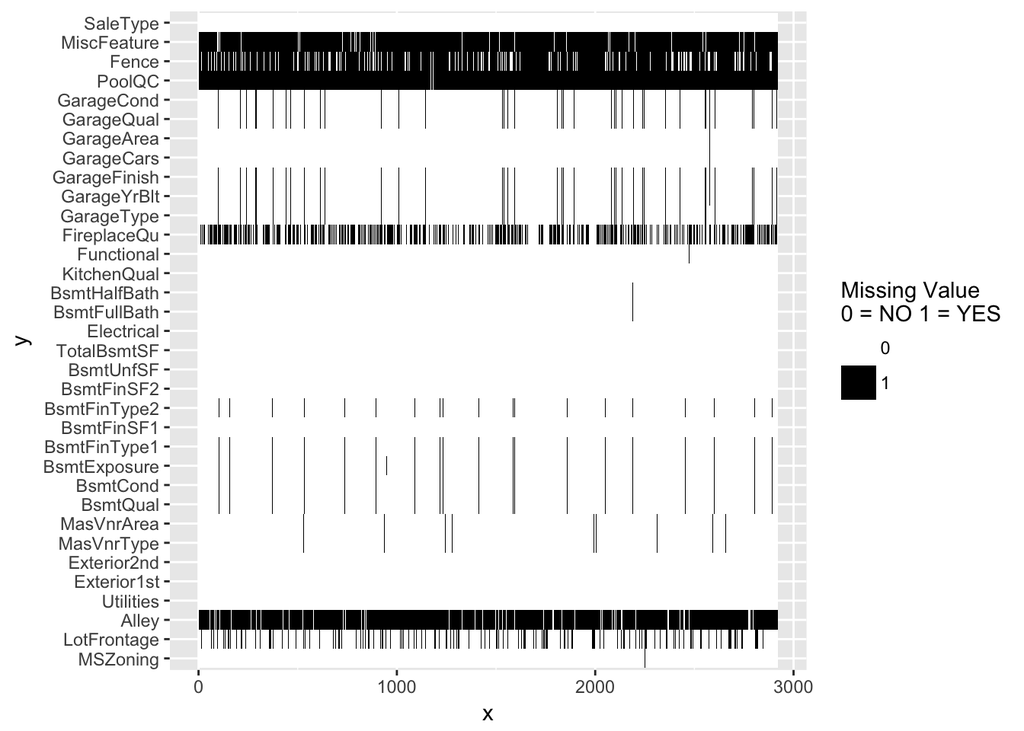

## Analyzing the factor MsSubClass

Definitions : Identifies the type of dwelling involved in the sale

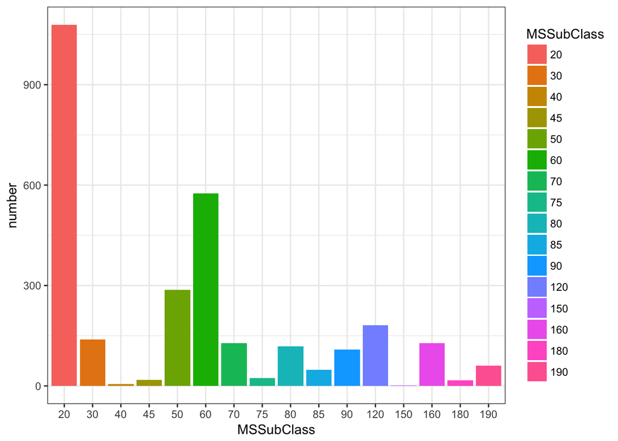

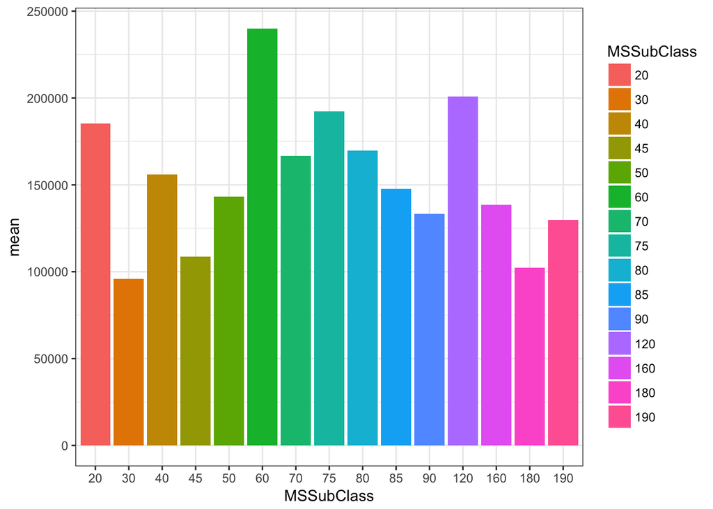

## Analyzing the MSZoning

Definitions : Identifies the general zoning classification of the sale  
Something weird is there is a category called A representing agriculture. However, it seems that A does not exist in the list of the categories.  
RP and I categories react the same way as well. Only testdata contains NA value.

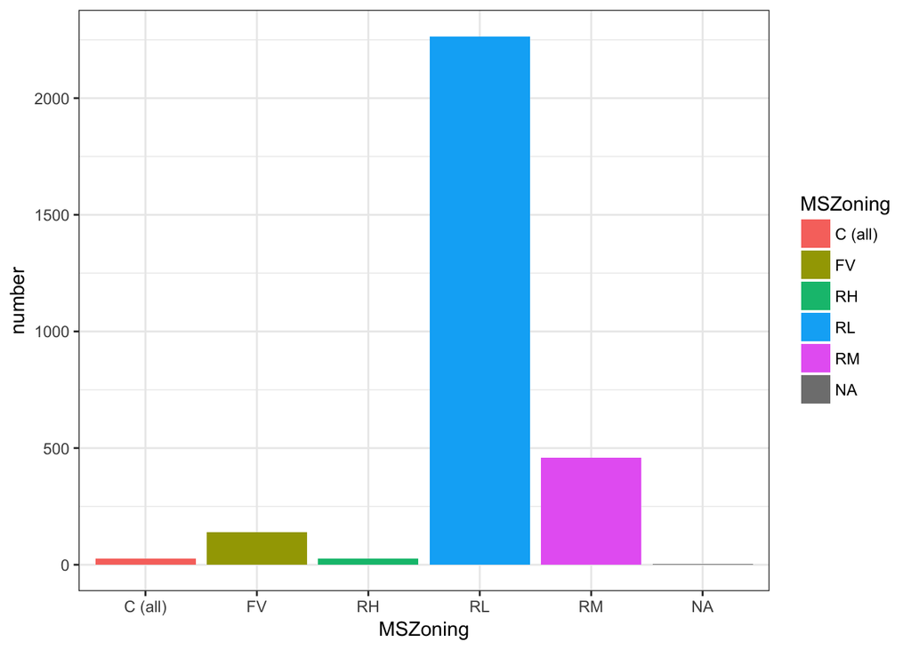

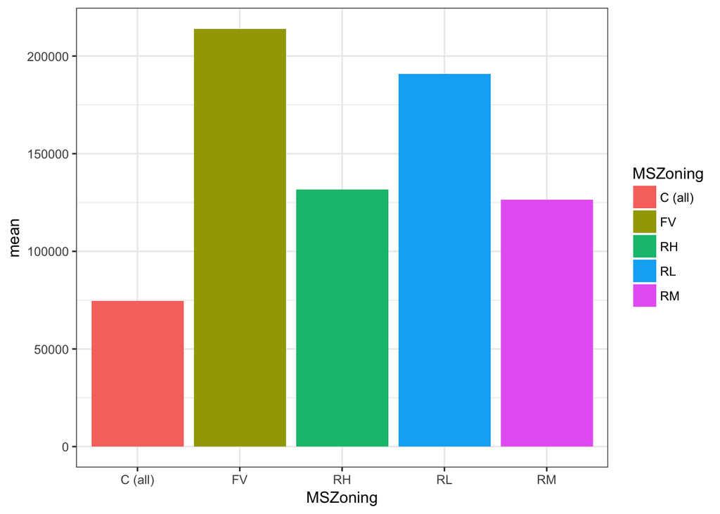

## Analyzing The LotFrontage

Definitions : Linear feet of street connected to property  
Viewing the distribution of entire vector except missing value  
It seems that tremendous missing values in LotFrontage vector does not relate to the average value of it, but the median value seems to be a little bit larger while the data in LogFrontage is missing. Hence, this indicates that the missing section contain much more higher value.

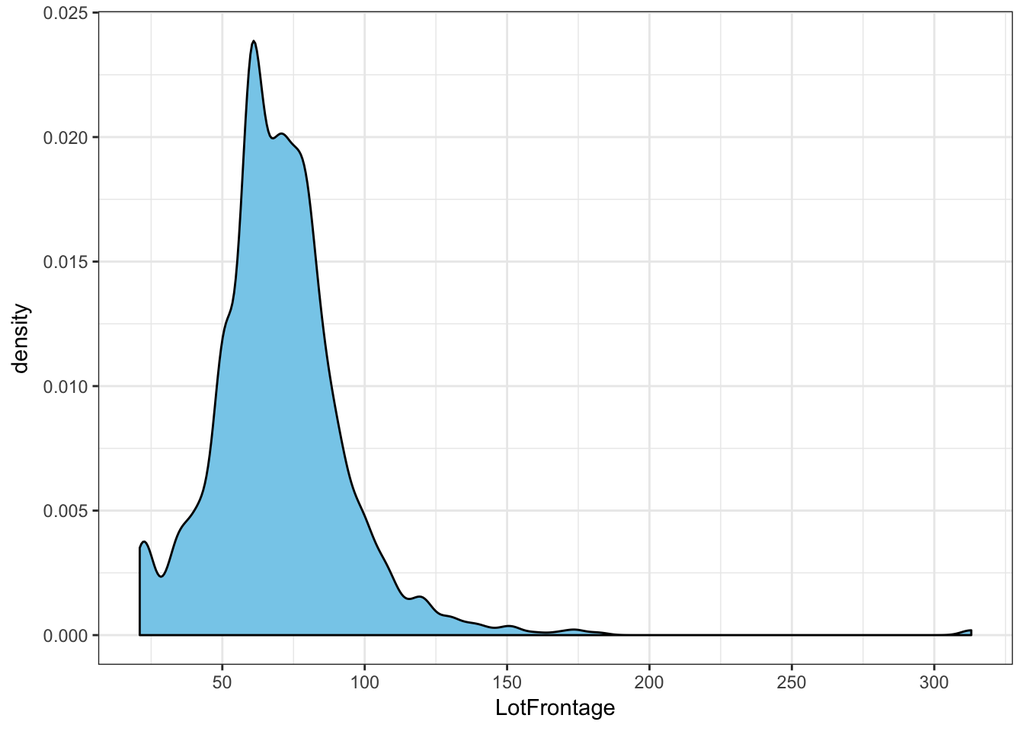

```
##    NAornot     mean median
## 1:   FALSE 180770.5 159500
## 2:    TRUE 181620.1 172400
```

## Analyzing LotArea

Definitions : Lot size in square feet  
There are 14 outliers whose value are greater than 50000 feat squares, I set the limitation of the plot on 50000. The maximum value is 200000.  
In general, we would assume that the size of lot is highly correlate with the sale price. Nonetheless, the stength correlation does not support this hypothesis.After all, the relationship between size of Lot and sale price is positive.

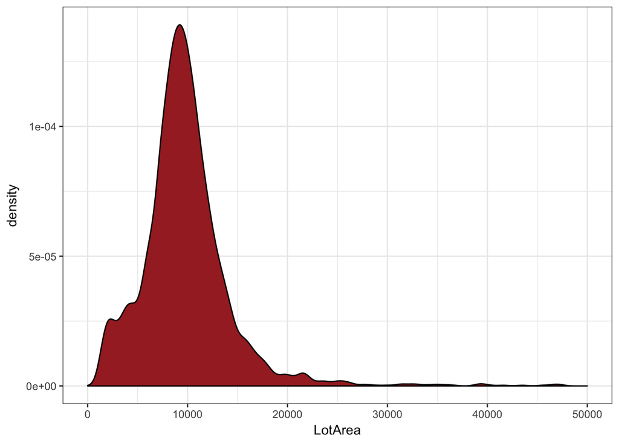

```
## [1] 0.2638434
```

## Analyzing Street

Definitions : Type of road access to property  
This factor is an awkward factor. It contains only 12 Grvl while other is pave. All in all, the street within Grvl might be much rougher or somewhat. The sale price in Grvl is much more cheaper than the one in pave. Hence, this factor could be a strong preditor.

```
##    Street number
## 1:   Pave   2907
## 2:   Grvl     12
```

```
##    Street     mean median
## 1:   Pave 181130.5 163000
## 2:   Grvl 130190.5 114250
```

## Analyzing Alley

Definitions : Type of alley access to property  
I don’t know if it is a coincidence that the house with a neiborhood with Grvl has reletively low mean sale price. This matchs the circumstance that the house in Grvl has relatively low sale price as well. However, the houses with no neiborhood are majority and it shows no giant difference with the houses with pave

```
##    Alley number
## 1:    NA   2721
## 2:  Grvl    120
## 3:  Pave     78
```

```
##    Alley     mean median
## 1:    NA 183452.1 165000
## 2:  Grvl 122219.1 119500
## 3:  Pave 168000.6 172500
```

## Analyzing LotShape

Definitions : General shape of property Firstly, I think the LotShape doesn’t matter, but it seems like that the most expensive objects are always with IR1 shape lot.  
Even though mean and median in Reg shape lot are relatively low, there are still tremendous outliers.

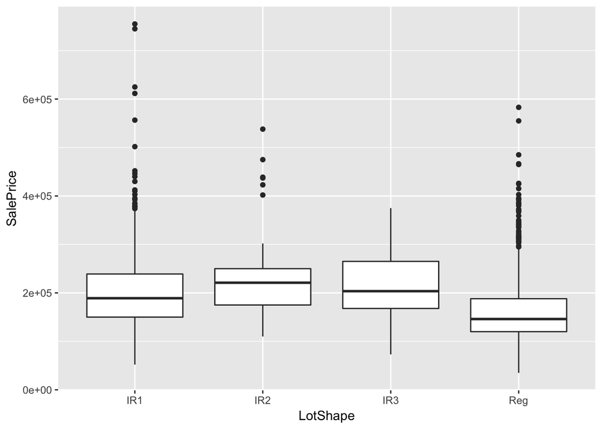

## Analyzing LandContour

Definitions : Flatness of the property  
Conspicuously, the houses with Bnk has very stable low sale price. Inspite of the fact that mean and median in LVl are relatively low, there are numerous outliers in LVl.

```
##    LandContour number
## 1:         Lvl   2622
## 2:         Bnk    117
## 3:         Low     60
## 4:         HLS    120
```

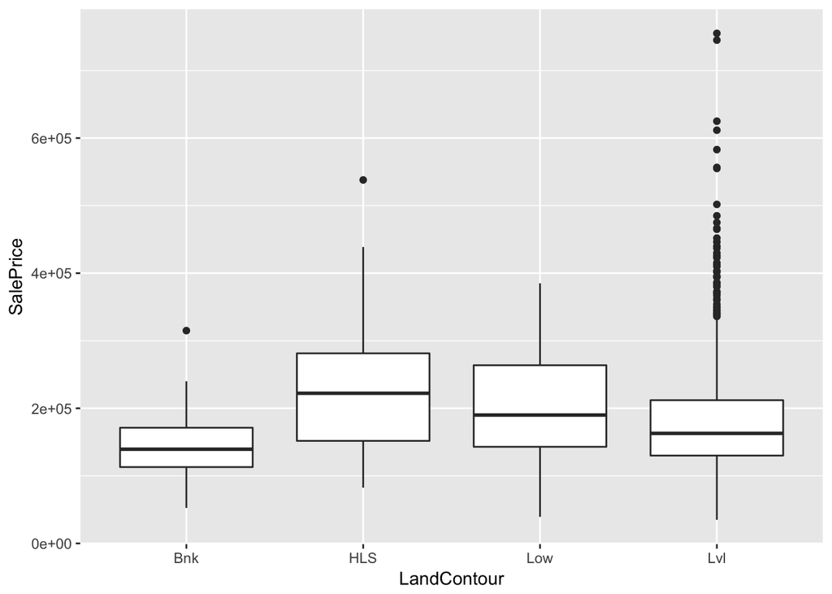

## Analyzing Utilities

Definitions : Type of utilities available  
After see the distribution of the feature. Set a hot coded feature might be a good way to explain it. Ther is only one house without water supply. Also, there are two NA value.

```
##    Utilities Number
## 1:    AllPub   2916
## 2:    NoSeWa      1
## 3:        NA      2
```

```
##    Utilities Number
## 1:    AllPub   1459
## 2:    NoSeWa      1
```

## Analyzing LotConfig

Definitions : Lot configuration

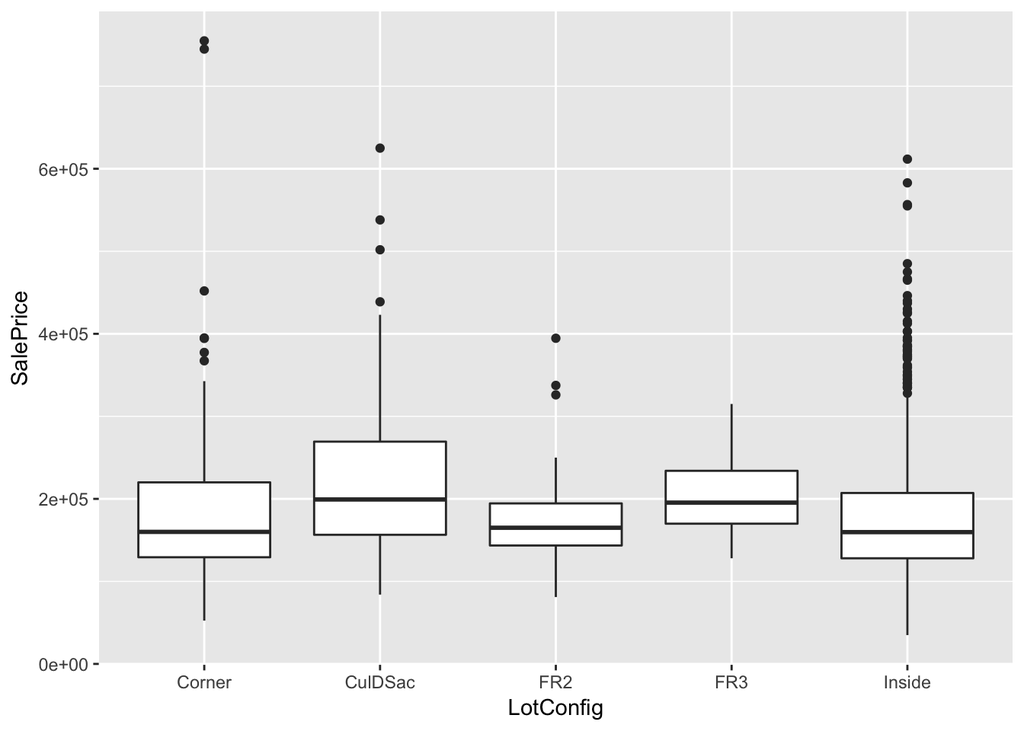